# Resumo do Capítulo 15 de R4DS: Expressões Regulares

Autor

Adaptado por Gemini

Data de Publicação

18 de setembro de 2025

## 15.1 Introdução

Este capítulo foca no uso de **expressões regulares** (regex), uma linguagem poderosa para descrever padrões em strings. Abordaremos os conceitos básicos, as funções mais úteis do `stringr` e `tidyr`, e detalhes mais avançados sobre a sintaxe dos padrões.

### 15.1.1 Pré-requisitos

Usaremos os pacotes `tidyverse` e `dados`. Também utilizaremos três vetores de caracteres do pacote `stringr`: `fruit`, `words` e `sentences`.

```r
library(tidyverse)
library(dados)
```

## 15.2 Padrões Básicos

Usaremos a função `str_view()` para visualizar como os padrões regex funcionam. Ela destaca as correspondências (matches) em um vetor de strings.

Os padrões mais simples são os **caracteres literais** (letras e números), que correspondem a si mesmos.

```r
str_view(fruit, "berry")
```

```
 [6] │ bil<berry>
 [7] │ black<berry>
[10] │ blue<berry>
[11] │ boysen<berry>
[19] │ cloud<berry>
[21] │ cran<berry>
[29] │ elder<berry>
[32] │ goji <berry>
[33] │ goose<berry>
[38] │ huckle<berry>
[50] │ mul<berry>
[70] │ rasp<berry>
[73] │ salal <berry>
[76] │ straw<berry>
```

Muitos outros caracteres, como `.`, `+`, `*`, `?`, são **metacaracteres** com significados especiais.

- `.` (ponto): Corresponde a **qualquer caractere**.

```r
# Encontra um "a" seguido por qualquer caractere
str_view(c("a", "ab", "ae", "bd", "ea", "eab"), "a.")
```

```
[2] │ <ab>
[3] │ <ae>
[6] │ e<ab>
```

- **Quantificadores:** Controlam quantas vezes um padrão pode ocorrer.
  - `?`: 0 ou 1 vez (opcional).
  - `+`: 1 ou mais vezes.
  - `*`: 0 ou mais vezes.

```r
# ab? : "a", opcionalmente seguido por "b"
str_view(c("a", "ab", "abb"), "ab?")
```

```
[1] │ <a>
[2] │ <ab>
[3] │ <ab>b
```

```r
# ab+ : "a", seguido por pelo menos um "b"
str_view(c("a", "ab", "abb"), "ab+")
```

```
[2] │ <ab>
[3] │ <abb>
```

```r
# ab* : "a", seguido por zero ou mais "b"s
str_view(c("a", "ab", "abb"), "ab*")
```

```
[1] │ <a>
[2] │ <ab>
[3] │ <abb>
```

- **Classes de Caracteres (`[]`):** Correspondem a qualquer caractere dentro dos colchetes. `[^...]` corresponde a qualquer caractere *exceto* os que estão nos colchetes.

```r
# Encontra palavras com "x" entre vogais
str_view(words, "[aeiou]x[aeiou]")
```

```
[284] │ <exa>ct
[285] │ <exa>mple
[288] │ <exe>rcise
[289] │ <exi>st
```

```r
# Encontra palavras com "y" entre consoantes
str_view(words, "[^aeiou]y[^aeiou]")
```

```
[836] │ <sys>tem
[901] │ <typ>e
```

- **Alternância (`|`):** Permite escolher entre múltiplos padrões.

```r
# Encontra frutas com "apple", "melon" ou "nut"
str_view(fruit, "apple|melon|nut")
```

```
 [1] │ <apple>
[13] │ canary <melon>
[20] │ coco<nut>
[52] │ <nut>
[62] │ pine<apple>
[72] │ rock <melon>
[80] │ water<melon>
```

```r
# Encontra frutas com vogais repetidas
str_view(fruit, "aa|ee|ii|oo|uu")
```

```
 [9] │ bl<oo>d orange
[33] │ g<oo>seberry
[47] │ lych<ee>
[66] │ purple mangost<ee>n
```

## 15.3 Funções Chave

### 15.3.1 Detectando Correspondências

`str_detect()` retorna `TRUE` se o padrão for encontrado e `FALSE` caso contrário. É ideal para usar com `filter()`.

```r
# Detecta quais strings contêm uma vogal
str_detect(c("a", "b", "c"), "[aeiou]")
```

```
[1]  TRUE FALSE FALSE
```

```r
# Filtra os nomes de bebês mais populares que contêm "x"
bebes |>
  filter(str_detect(nome, "x")) |>
  count(nome, wt = n, sort = TRUE)
```

```
# A tibble: 974 × 2
   nome            n
   <chr>       <int>
 1 Alexander  665492
 2 Alexis     399551
 3 Alex       278705
 4 Alexandra  232223
 5 Max        148787
 6 Alexa      123032
 7 Maxine     112261
 8 Alexandria  97679
 9 Maxwell     90486
10 Jaxon       71234
# ℹ 964 more rows
```

Com `summarize()`, podemos calcular a contagem (`sum()`) ou a proporção (`mean()`) de correspondências.

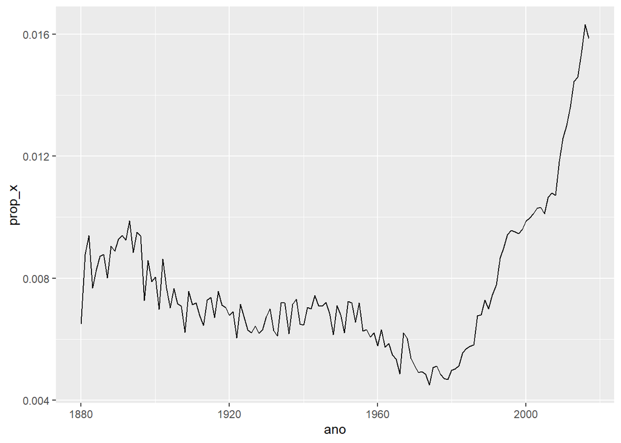

```r
# Proporção de nomes de bebês com "x" ao longo dos anos
bebes |>
  group_by(ano) |>
  summarize(prop_x = mean(str_detect(nome, "x"))) |>
  ggplot(aes(x = ano, y = prop_x)) +
  geom_line()
```

### 15.3.2 Contando Correspondências

`str_count()` informa *quantas* correspondências existem em cada string. As correspondências de regex nunca se sobrepõem.

```r
x <- c("apple", "banana", "pear")
str_count(x, "p")
```

```
[1] 2 0 1
```

```r
# "aba" corresponde duas vezes em "abababa", não três
str_count("abababa", "aba")
```

```
[1] 2
```

```r
str_view("abababa", "aba")
```

```
[1] │ <aba>b<aba>
```

As expressões regulares diferenciam maiúsculas de minúsculas. Para ignorar essa diferença, podemos modificar o padrão (`"[aeiouAEIOU]"`), usar a função `regex()` com `ignore_case = TRUE`, ou pré-processar a string com `str_to_lower()`.

```r
# Contando vogais e consoantes (após converter para minúsculas)
bebes |>
  count(nome) |>
  mutate(
    nome = str_to_lower(nome),
    vogais = str_count(nome, "[aeiou]"),
    consoantes = str_count(nome, "[^aeiou]")
  )
```

```
# A tibble: 97,310 × 4
   nome          n vogais consoantes
   <chr>     <int>  <int>      <int>
 1 aaban        10      3          2
 2 aabha         5      3          2
 3 aabid         2      3          2
 4 aabir         1      3          2
 5 aabriella     5      5          4
 6 aada          1      3          1
 7 aadam        26      3          2
 8 aadan        11      3          2
 9 aadarsh      17      3          4
10 aaden        18      3          2
# ℹ 97,300 more rows
```

### 15.3.3 Trocando Valores

`str_replace()` troca a primeira correspondência, enquanto `str_replace_all()` troca todas. `str_remove()` e `str_remove_all()` são atalhos para remover padrões.

```r
x <- c("apple", "pear", "banana")
str_replace_all(x, "[aeiou]", "-")
```

```
[1] "-ppl-"  "p--r"   "b-n-n-"
```

```r
x <- c("apple", "pear", "banana")
str_remove_all(x, "[aeiou]")
```

```
[1] "ppl" "pr"  "bnn"
```

### 15.3.4 Extraindo Variáveis

`tidyr::separate_wider_regex()` extrai dados de uma coluna para múltiplas novas colunas usando regex. Para cada parte que queremos extrair, damos um nome no argumento `patterns`. As partes que não queremos extrair ficam sem nome.

```r
df <- tribble(
  ~str,
  "<Sheryl>-F_34",
  "<Kisha>-F_45",
  "<Brandon>-M_33",
  "<Sharon>-F_38",
  "<Penny>-F_58",
  "<Justin>-M_41",
  "<Patricia>-F_84",
)

df |>
  separate_wider_regex(
    str,
    patterns = c(
      "<",
      nome = "[A-Za-z]+",
      ">-",
      sexo_biologico = ".",
      "_",
      idade = "[0-9]+"
    )
  )
```

```
# A tibble: 7 × 3
  nome     sexo_biologico idade
  <chr>    <chr>          <chr>
1 Sheryl   F              34
2 Kisha    F              45
3 Brandon  M              33
4 Sharon   F              38
5 Penny    F              58
6 Justin   M              41
7 Patricia F              84
```

## 15.4 Detalhes de Padrões

### 15.4.1 Escapando Caracteres

Para corresponder a um metacaractere literal (como `.`), você precisa “escapá-lo” com uma barra invertida (`\`). Como as strings em R também usam `\` para escape, você precisa digitar duas barras invertidas (`\\.`) para criar uma expressão regular que corresponda a um ponto.

```r
# Para criar a regex \., usamos a string "\\."
ponto <- "\\."
str_view(ponto) # A regex em si tem apenas uma barra
```

```
[1] │ \.
```

```r
# Isso busca um ponto literal
str_view(c("abc", "a.c", "bef"), "a\\.c")
```

```
[2] │ <a.c>
```

Para corresponder a uma `\` literal, você precisa digitar `\\\\`.

### 15.4.2 Âncoras

Âncoras forçam a correspondência a ocorrer em posições específicas:

- `^`: Início da string.
- `$`: Fim da string.
- `\b`: Limite de palavra (o início ou o fim de uma palavra).

```r
str_view(fruit, "^a") # Frutas que começam com "a"
```

```
[1] │ <a>pple
[2] │ <a>pricot
[3] │ <a>vocado
```

```r
str_view(fruit, "a$") # Frutas que terminam com "a"
```

```
 [4] │ banan<a>
[15] │ cherimoy<a>
[30] │ feijo<a>
[36] │ guav<a>
[56] │ papay<a>
[74] │ satsum<a>
```

```r
# Força a correspondência da string inteira
str_view(fruit, "^apple$")
```

```
[1] │ <apple>
```

```r
# \b encontra a palavra "sum" exata
x <- c("summary(x)", "summarize(df)", "rowsum(x)", "sum(x)")
str_view(x, "\\bsum\\b")
```

```
[4] │ <sum>(x)
```

### 15.4.3 Classes de Caracteres e Atalhos

Além de `.` e `[]`, existem outros atalhos úteis:

- `\d`: Qualquer dígito. `\D`: Qualquer não-dígito.
- `\s`: Qualquer espaço em branco (espaço, tab, nova linha). `\S`: Qualquer não-espaço.
- `\w`: Qualquer caractere de “palavra” (letras e números). `\W`: Qualquer não-palavra.

```r
x <- "abcd ABCD 12345 -!@#%."
str_view(x, "\\d+") # Corresponde aos dígitos
```

```
[1] │ abcd ABCD <12345> -!@#%.
```

```r
str_view(x, "\\s+") # Corresponde aos espaços
```

```
[1] │ abcd< >ABCD< >12345< >-!@#%.
```

```r
str_view(x, "\\w+") # Corresponde a letras e números
```

```
[1] │ <abcd> <ABCD> <12345> -!@#%.
```

### 15.4.4 Quantificadores Detalhados

Além de `?`, `+`, e `*`, você pode especificar o número exato de correspondências com `{}`:

- `{n}`: Exatamente `n` vezes.
- `{n,}`: Pelo menos `n` vezes.
- `{n,m}`: Entre `n` e `m` vezes.

### 15.4.5 Precedência e Parênteses

Assim como na aritmética, as regex têm regras de precedência. Quantificadores (`+`, `*`) têm alta precedência, e a alternância (`|`) tem baixa. * `ab+` significa `a(b+)`. * `^a|b$` significa `(^a)|(b$)`.

Na dúvida, **use parênteses `()`** para garantir a ordem correta das operações.

### 15.4.6 Agrupamento e Captura

Parênteses `()` também criam **grupos de captura**, permitindo extrair e referenciar subcomponentes da correspondência.

- **Referências Anteriores (Backreferences):** Dentro de um padrão, `\1` se refere ao que foi capturado pelo primeiro grupo, `\2` ao segundo, e assim por diante.

```r
# Encontra frutas com um par de letras repetido
str_view(fruit, "(..)\\1")
```

```
 [4] │ b<anan>a
[20] │ <coco>nut
[22] │ <cucu>mber
[41] │ <juju>be
[56] │ <papa>ya
[73] │ s<alal> berry
```

```r
# Encontra palavras que começam e terminam com o mesmo par de letras
str_view(words, "^(..).*\\1$")
```

```
[152] │ <church>
[217] │ <decide>
[617] │ <photograph>
[699] │ <require>
[739] │ <sense>
```

Você também pode usar referências anteriores em `str_replace()` para reorganizar partes de uma string.

```r
# Troca a ordem da segunda e terceira palavras
sentences |>
  str_replace("(\\w+) (\\w+) (\\w+)", "\\1 \\3 \\2") |>
  str_view()
```

```
 [1] │ The canoe birch slid on the smooth planks.
 [2] │ Glue sheet the to the dark blue background.
 [3] │ It's to easy tell the depth of a well.
 [4] │ These a days chicken leg is a rare dish.
 [5] │ Rice often is served in round bowls.
 [6] │ The of juice lemons makes fine punch.
 [7] │ The was box thrown beside the parked truck.
 [8] │ The were hogs fed chopped corn and garbage.
 [9] │ Four of hours steady work faced us.
[10] │ A size large in stockings is hard to sell.
[11] │ The was boy there when the sun rose.
[12] │ A is rod used to catch pink salmon.
[13] │ The of source the huge river is the clear spring.
[14] │ Kick ball the straight and follow through.
[15] │ Help woman the get back to her feet.
[16] │ A of pot tea helps to pass the evening.
[17] │ Smoky lack fires flame and heat.
[18] │ The cushion soft broke the man's fall.
[19] │ The breeze salt came across from the sea.
[20] │ The at girl the booth sold fifty bonds.
... and 700 more
```

Para extrair o conteúdo de cada grupo, use `str_match()`. No entanto, `separate_wider_regex()` é geralmente uma abordagem mais `tidyverse` para este problema.

Para usar parênteses para agrupamento sem criar um grupo de captura, use `(?:...)`.

## 15.5 Controle de Padrões

É possível ter mais controle sobre a correspondência envolvendo o padrão em uma função auxiliar.

### 15.5.1 Sinalizadores Regex

A função `regex()` permite ajustar o comportamento da regex com “sinalizadores” (flags):

- `ignore_case = TRUE`: Ignora a diferença entre maiúsculas e minúsculas.

```r
bananas <- c("banana", "Banana", "BANANA")
str_view(bananas, regex("banana", ignore_case = TRUE))
```

```
[1] │ <banana>
[2] │ <Banana>
[3] │ <BANANA>
```

- `multiline = TRUE`: Faz com que `^` e `$` correspondam ao início e fim de cada linha, em vez da string inteira.
- `comments = TRUE`: Permite adicionar comentários e espaços em branco à sua regex para torná-la mais legível.

### 15.5.2 Correspondências Fixas

Para desativar completamente as regras de regex e corresponder a uma string literal, use `fixed()`. Para comparações sensíveis à localidade (idioma), use `coll()`.

```r
str_view(c("", "a", "."), fixed("."))
```

```
[3] │ <.>
```

## 15.6 Prática

### 15.6.1 Verificando seu Trabalho

Ao construir uma regex, é útil criar vetores de teste com correspondências positivas (que devem corresponder) e negativas (que não devem) para verificar se seu padrão está funcionando como esperado.

```r
# Queremos encontrar frases que começam com um pronome
pos <- c("Ele é jovem", "Elas se divertiram")
neg <- c("Eleitores não compareceram na data correta", "Hadley nos disse 'É um ótimo dia!'")

padrao <- "^(Eu|Tu|Ele|Ela|Nós|Vós|Eles|Elas)\\b"
str_detect(pos, padrao)
```

```
[1] TRUE TRUE
```

```r
str_detect(neg, padrao)
```

```
[1] FALSE FALSE
```

### 15.6.2 Operações Booleanas

Às vezes, é mais fácil resolver um problema invertendo-o ou combinando múltiplos `str_detect()` com operadores lógicos (`&`, `|`, `!`) do que construir uma única regex complexa.

```r
# Encontrar palavras com "a" E "b" é mais fácil com `&`
words[str_detect(words, "a") & str_detect(words, "b")]
```

```
 [1] "able"      "about"     "absolute"  "available" "baby"      "back"
 [7] "bad"       "bag"       "balance"   "ball"      "bank"      "bar"
[13] "base"      "basis"     "bear"      "beat"      "beauty"    "because"
[19] "black"     "board"     "boat"      "break"     "brilliant" "britain"
[25] "debate"    "husband"   "labour"    "maybe"     "probable"  "table"
```

```r
# Encontrar palavras que NÃO contêm vogais
words[!str_detect(words, "[aeiou]")]
```

```
[1] "by"  "dry" "fly" "mrs" "try" "why"
```

### 15.6.3 Criando um Padrão com Código

Quando você tem uma longa lista de palavras para procurar, pode construir a regex programaticamente usando `str_c()` e `str_flatten()`.

```r
# Encontrar frases que mencionam cores do R
cores <- colors()
cores <- cores[!str_detect(cores, "\\d")] # Remove cores com números

# Cria um padrão gigante: "\\b(white|aliceblue|...)\\b"
padrao <- str_c("\\b(", str_flatten(cores, "|"), ")\\b")

str_view(sentences, padrao)
```

```
  [2] │ Glue the sheet to the dark <blue> background.
 [12] │ A rod is used to catch <pink> <salmon>.
 [26] │ Two <blue> fish swam in the tank.
 [66] │ Cars and busses stalled in <snow> drifts.
 [92] │ A wisp of cloud hung in the <blue> air.
[112] │ Leaves turn <brown> and <yellow> in the fall.
[148] │ The spot on the blotter was made by <green> ink.
[149] │ Mud was spattered on the front of his <white> shirt.
[160] │ The sofa cushion is <red> and of light weight.
[167] │ The office paint was a dull, sad <tan>.
[174] │ The sky that morning was clear and bright <blue>.
[201] │ The <brown> house was on fire to the attic.
[204] │ A <blue> crane is a tall wading bird.
[217] │ It is hard to erase <blue> or <red> ink.
[221] │ A pencil with <black> lead writes best.
[224] │ The lamp shone with a steady <green> flame.
[230] │ Slash the <gold> cloth into fine ribbons.
[234] │ They floated on the raft to sun their <white> backs.
[246] │ The birch looked stark <white> and lonesome.
[247] │ The box is held by a bright <red> snapper.
... and 43 more
```

## Tabela de Funções

| Função | Descrição |
| --- | --- |
| `str_view(string, pattern)` | Exibe as correspondências de um padrão em um vetor de caracteres. Ideal para aprendizado. |
| `str_detect(string, pattern)` | Retorna `TRUE`/`FALSE` se o padrão for encontrado. Ótimo para usar com `filter()`. |
| `str_count(string, pattern)` | Conta o número de correspondências em cada string. |
| `str_replace(string, pattern, replacement)` | Substitui a primeira correspondência do padrão. |
| `str_replace_all(string, pattern, replacement)` | Substitui todas as correspondências do padrão. |
| `str_remove(string, pattern)` | Remove a primeira correspondência (atalho para `str_replace(..., replacement = "")`). |
| `str_remove_all(string, pattern)` | Remove todas as correspondências. |
| `str_match(string, pattern)` | Extrai o conteúdo dos grupos de captura de uma regex para uma matriz. |
| `separate_wider_regex(data, col, patterns)` | (Do `tidyr`) Extrai dados de uma coluna para novas colunas usando regex nomeadas. |
| `regex(pattern, ...)` | Modifica o comportamento de uma regex com sinalizadores (`ignore_case`, `multiline`, etc.). |
| `fixed(pattern)` | Trata o padrão como uma string literal, desativando a regex. |
| `coll(pattern, locale)` | Corresponde a uma string literal, mas respeitando as regras de ordenação de um idioma. |